# EDA on Prosper loan data

The plot also shows that borrowers with good credit grade (“AA” - “B”) have comparatively fewer troubled loans and more completed loans.

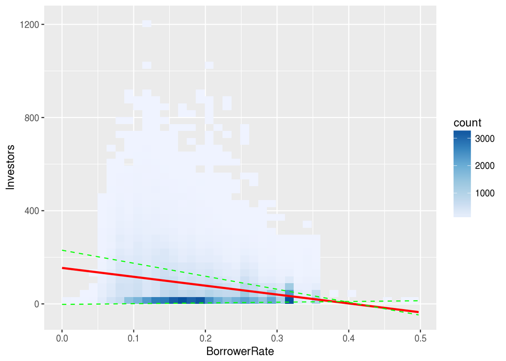

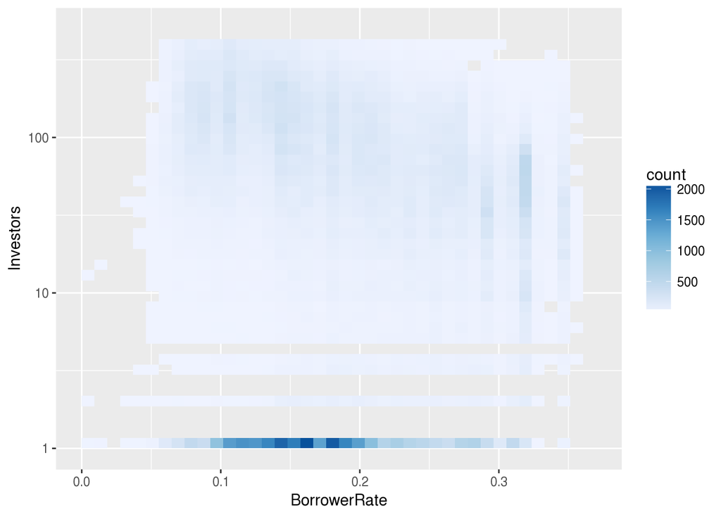

The two plots above display the relationship between the BorrowerRate and the number of investors of a loan. A heatmap was chosen, as the scatter plot showed too much overplotting.

Plot 1 features the complete dataset and a linear regression (red line) of the linear relationship between the number of investors and the BorrowerRate. The two green lines are the 25% and 75% quantile. It becomes clear that there are hardly any investors that are willing to fund a loan with a rate >0.4. The risk is probably too high, as those high rates are associated with dubious borrowers .

Plot 2 zooms in on the first plot and uses a log10-transformed y-axis. It shows the clustered nature of investor’s engagement and the negative relationship between the two variables (visible in the darker patches of the light-blue area) .

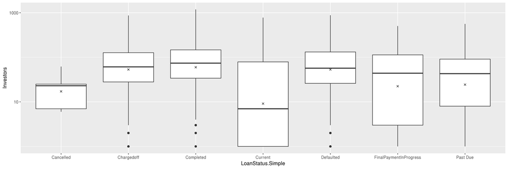

```
## pr_df$LoanStatus.Simple: Cancelled
##    Min. 1st Qu.  Median    Mean 3rd Qu.    Max.
##     6.0     7.0    23.0    24.6    25.0    62.0
## --------------------------------------------------------
## pr_df$LoanStatus.Simple: Chargedoff
##    Min. 1st Qu.  Median    Mean 3rd Qu.    Max.
##    1.00   28.00   61.00   96.11  127.00  870.00
## --------------------------------------------------------
## pr_df$LoanStatus.Simple: Completed
##    Min. 1st Qu.  Median    Mean 3rd Qu.    Max.
##     1.0    34.0    74.0   108.3   147.0  1189.0
## --------------------------------------------------------
## pr_df$LoanStatus.Simple: Current
##    Min. 1st Qu.  Median    Mean 3rd Qu.    Max.
##    1.00    1.00    7.00   57.57   79.00  779.00
## --------------------------------------------------------
## pr_df$LoanStatus.Simple: Defaulted
##    Min. 1st Qu.  Median    Mean 3rd Qu.    Max.
##     1.0    26.0    57.0   100.7   132.0   881.0
## --------------------------------------------------------
## pr_df$LoanStatus.Simple: FinalPaymentInProgress
##    Min. 1st Qu.  Median    Mean 3rd Qu.    Max.
##     1.0     3.0    44.0    77.5   113.5   504.0
## --------------------------------------------------------
## pr_df$LoanStatus.Simple: Past Due
##    Min. 1st Qu.  Median    Mean 3rd Qu.    Max.
##    1.00    8.00   43.00   69.05   91.00  563.00
```

I cannot tell a clear relationship from this plot. The loan status “Cancelled” seems to be low on investors, but there are very loans with this status, so the comparability may not be given. “Current” loans show a highly skewed distribution, as the mean and the median are far apart - there must be some loans with a huge number of investors in this category.

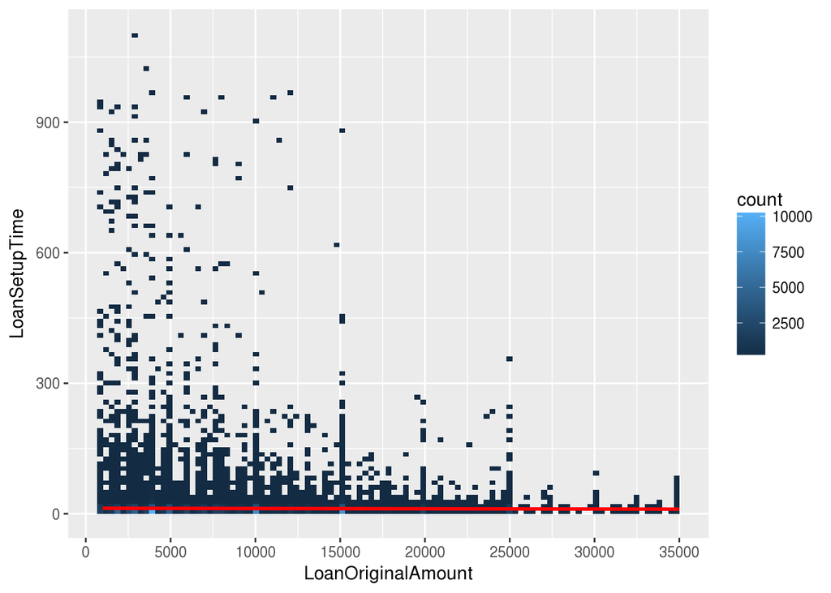

The plot shows the loan setup time over the loan amount. Although there are some outliers for smaller loan amounts, there is no visible relationship between the two variables. The linear regression line is plotted in red and is essentially flat.

# Bivariate Analysis

### Talk about some of the relationships you observed in this part of the investigation. How did the feature(s) of interest vary with other features in the dataset?

As I am interested in the determinants of the loan status, I was looking at the main variables AllCreditGrade, the BorrowerRate and the StatedMonthlyIncome.

Interestingly, the StatedMonthlyIncome is also related to the credit grade - a higher median income tends to be associated with a better credit grade, but there are numerous outliers and the relationship does not hold for minimum and maximum income values per credit grade.

### Did you observe any interesting relationships between the other features (not the main feature(s) of interest)?

I found the timeseries based on originated loans pretty interesting, as you could both see the business development of Prosper and the changing lending policies.

# Multivariate Plots Section

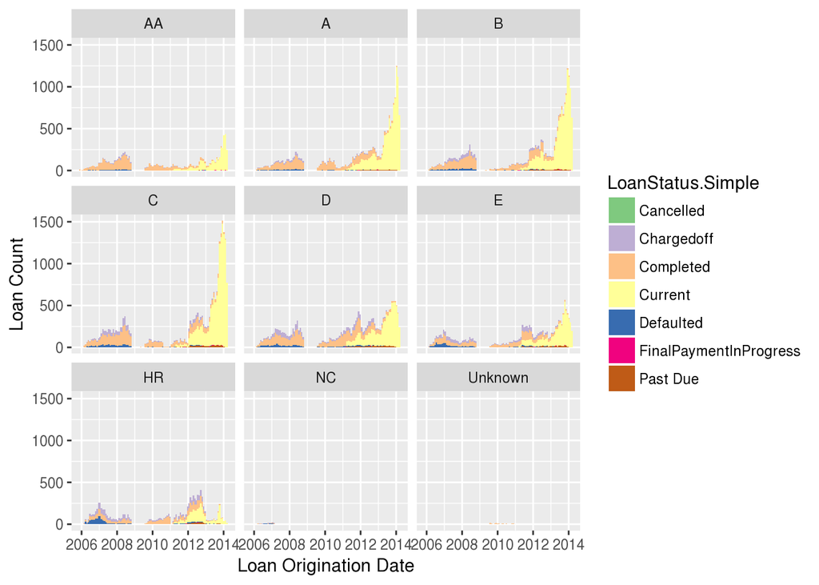

This is a detailed view of the corresponding bivariate plot, using the variable AllCreditGrade as a facet. The bars in the histograms are subdivided by the variable LoanStatus.Simple, which allows us to see the temporal distribution of this variable per credit grade. Especially the “HR” (but also the “E) credit grade is interesting: between 2006 and end of 2008, a large proportion of those loans turned out to be troubled (defaulted or chargedoff). The problem with this plot lies in the fact, that the loan status is a delayed indicator. In the worst case, it takes the complete loan lifecycle to find out, that the borrower cannot pay. That may take up to 5 years. It is therefore not surprising that we see very little troubled loans after 2010.

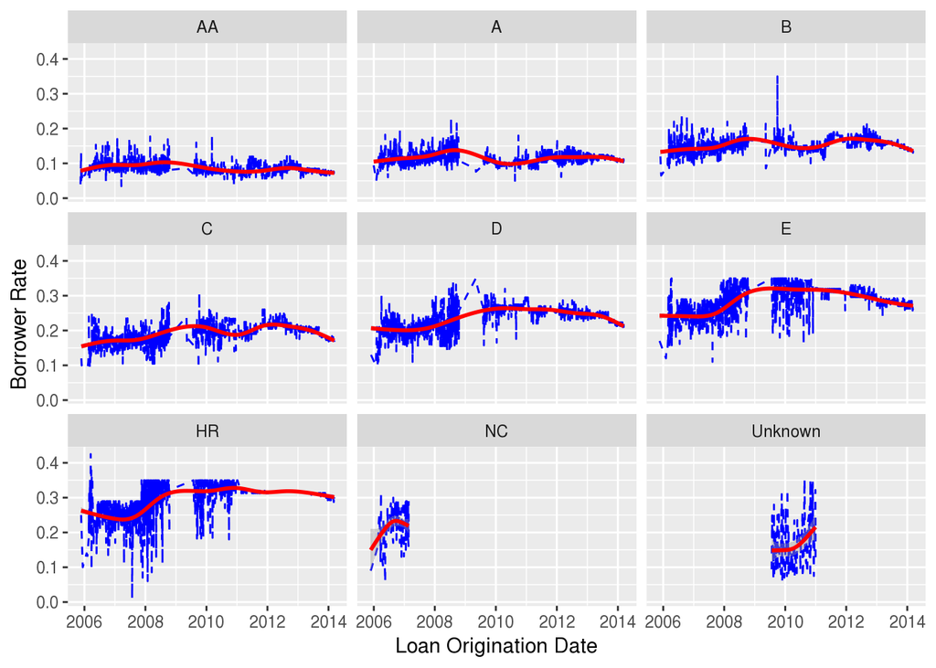

The above plot shows the temporal distribution of the median BorrowerRate, instead of the number of loans, as in the plot before. Here, the impact of the financial crisis is plainly visible: from mid-2007 on, the rates go up and remain on a higher level for borrowers with a low credit grade (esp. “D”, “E” and “HR”), whereas borrowers with good credit grade remain largely unaffected. The rates seem to come down a little after 2013, though.

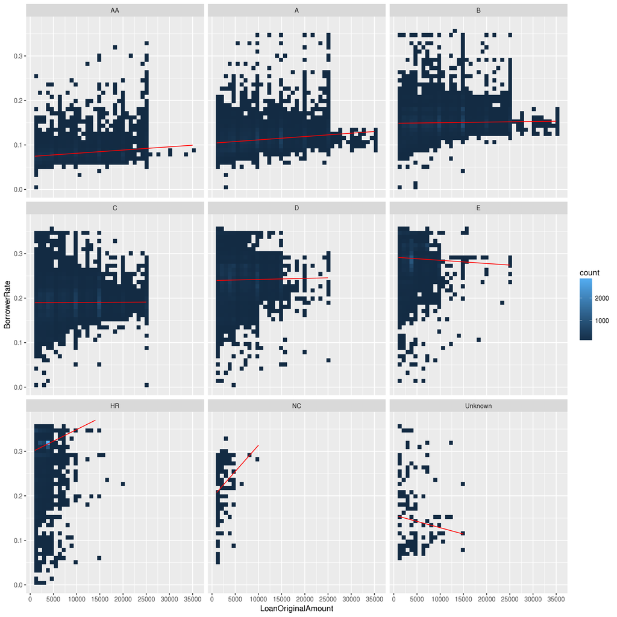

This expanded view of the corresponding bivariate plot clarifies the question, why we don’t see more large loans handed out. Loan amounts larger than $25.000 only go to borrowers with a credit grade “B” or better. It is also instructive to see how the BorrowerRate is depending on the credit grade; the median line for this variable is plotted in red. The highest loan count can be found in the “HR” facet panel. It also has the highest median rate. This means that loan origination for these borrowers is extremely concentrated on this type of loan (amount ca. $4000, rate ca. 0.32).

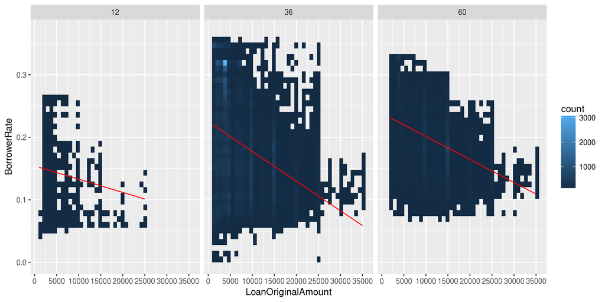

```
## pr_df$Term: 12
##    Min. 1st Qu.  Median    Mean 3rd Qu.    Max.
##  0.0400  0.0929  0.1434  0.1501  0.2064  0.2669
## --------------------------------------------------------
## pr_df$Term: 36
##    Min. 1st Qu.  Median    Mean 3rd Qu.    Max.
##  0.0000  0.1274  0.1824  0.1937  0.2599  0.4975
## --------------------------------------------------------
## pr_df$Term: 60
##    Min. 1st Qu.  Median    Mean 3rd Qu.    Max.
##  0.0669  0.1490  0.1870  0.1932  0.2333  0.3304
```

The 36 and 60 months facet only show minor differences: the 36 month facet includes a wider span of borrower rates, but the median borrower rate looks pretty similar. Moreover, larger loan >$15.000 with elevated borrower rates >0.26 only exist for medium term loans, not long term loans (at least in this dataset).

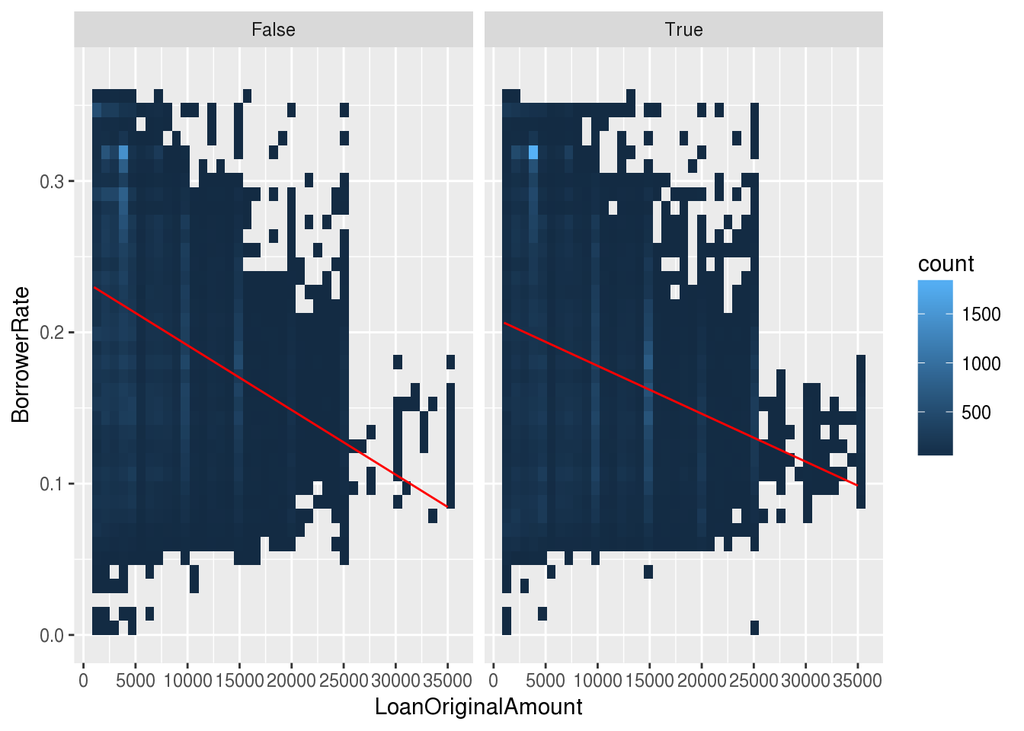

```
## pr_df$IsBorrowerHomeowner: False
##    Min. 1st Qu.  Median    Mean 3rd Qu.    Max.
##  0.0000  0.1449  0.1980  0.2031  0.2624  0.4975
## --------------------------------------------------------
## pr_df$IsBorrowerHomeowner: True
##    Min. 1st Qu.  Median    Mean 3rd Qu.    Max.
##  0.0000  0.1239  0.1700  0.1830  0.2398  0.3600
```

Home ownership seems to have only a minimal impact on loan origination; the median BorrowerRate seems to be lower though, which makes sense, as the house could act as a collateral.

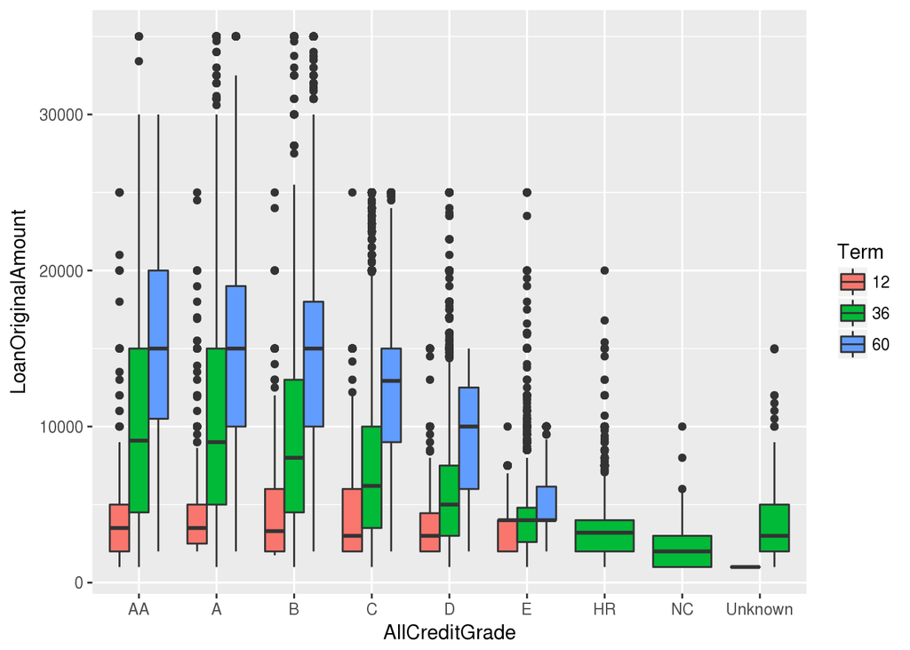

This expanded view of the corresponding bivariate plot includes the Term variable. It shows nicely, that the loan amount is directly proportional to the loan terms, i.e. longer-running loans tend to be larger, almost independent from the credit grade.

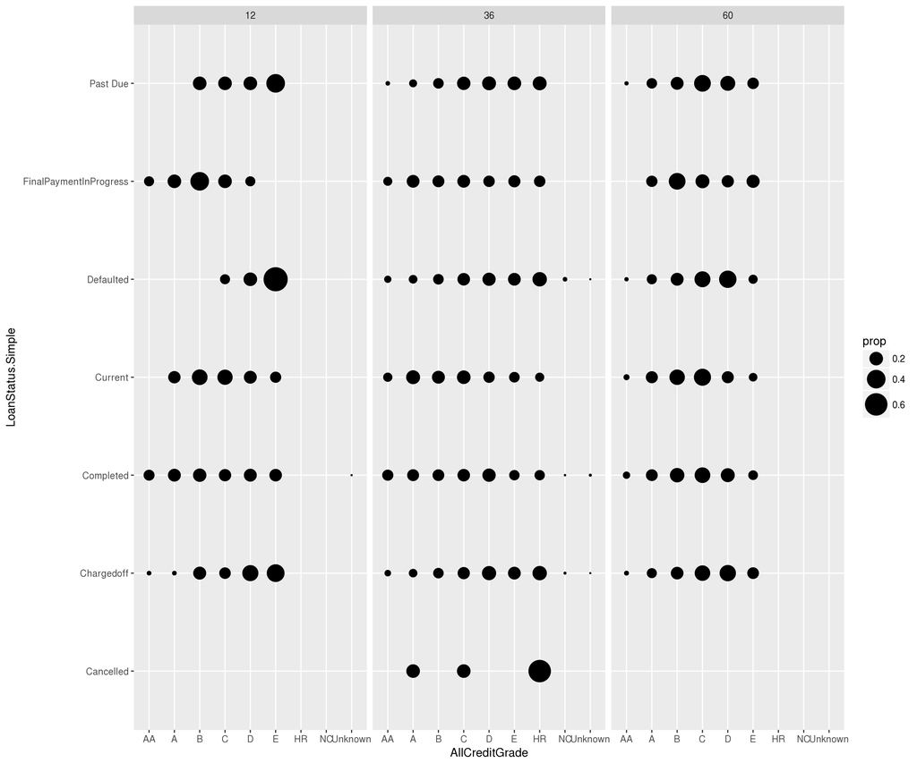

This expanded view of the corresponding bivariate plot includes the Term variable. The point size is the percent of loans in that panel at that position, grouped by the term and the loan status. The 12 month facet may be unreliable, as the dataset only contains relatively few of these loans; I’ll focus on the 36 and 60 months facet and compare those to judge the added value of the term variable. It seems, we see the same pattern concerning troubled loans as before. So the term variable may not help us much here.

# Multivariate Analysis

### Talk about some of the relationships you observed in this part of the investigation. Were there features that strengthened each other in terms of looking at your feature(s) of interest?

The loan status (variable LoanStatus.Simple) and the credit grade (variable AllCreditGrade) in combination really clear up the business development of Prosper (as far as the dataset allows).

The credit grade also better explains the relationship between the loan amount and the borrower rate. Certain borrowers with bad credit grade are severely limited in their loan conditions.

### Were there any interesting or surprising interactions between features?

I found it surprising that the loan term has only a minor explanatory value; I would have expected, that short and long loans are handed out differently, depending on the other borrower characteristics.

The loan origination date and the credit grade heavily influence the BorrowerRate, especially for low credit grades, probably due to the financial crisis from 2007 on.

### OPTIONAL: Did you create any models with your dataset?

I did not create a model with the dataset.

# Final Plots and Summary

### Plot One

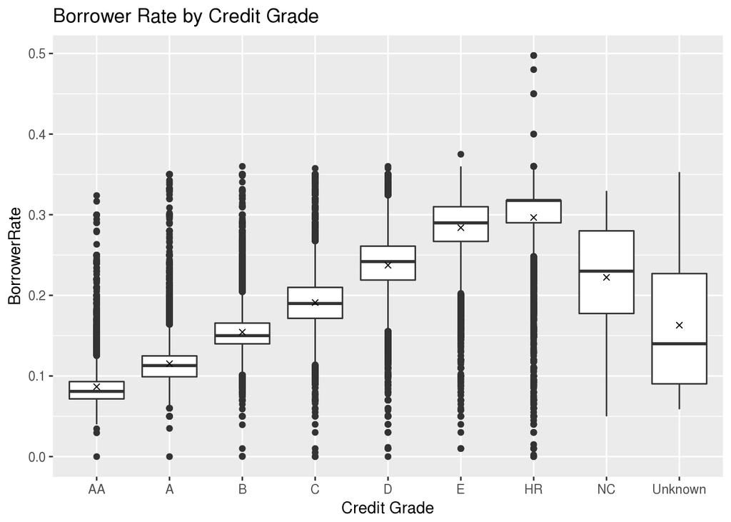

### Plot Two

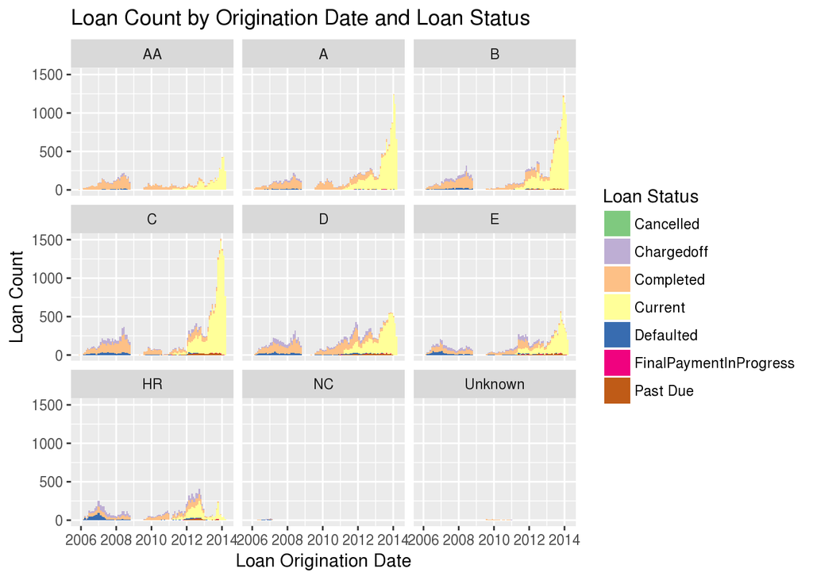

### Description Two

The longitudinal view on the data reveals the up and downs of Prospers business.

It is very interesting to see the total lack of granted loans between Nov. 2008 and mid-2009; the reason was a SEC decision to regulate Prospers business model (see https://techcrunch.com/2008/11/26/sec-outlines-its-reasoning-for-shutting-down-p2p-lender-prosper/). It is unclear whether the subprime mortgage crisis in 2007 and 2008 is related to the temporary shutdown of Prosper; the housing market already showed massive problems due to subprime mortgages in 2007 already, but Prosper’s business was still going steady by then.

The loan status adds another dimension to this plot, which is most insightful up to mid-2011. Most loans run for 3 years, so by mid-2014, they should have run their course and the final loan status is available. The proportion of loans with status “Current”" becomes dominant from 2011 on. These loans were originated and are still running or are past due (by the end of 2014). For most of them, their final loan status is unknown.

Prosper makes most of their business with borrowers having a credit grade between “A” and “C”, especially from 2013 on. However, the temporal distribution is pretty different among the credit grades. Something interesting must have happened for the “C” credit grade - it seems, Prosper originated almost no loans in the second half of 2010, but ramped up loan origination massively from 2012 on.

The loan origination to HR credit grade was reduced, as it seems; from 2013 on, HR loans do not participate in the overall uptake of the loan business, but only show a very small peak, that disappears by 2014. Another explanation would be a redefinition of the “HR” credit grade, such that more borrowers would be classified with a better credit grade.

### Plot Three

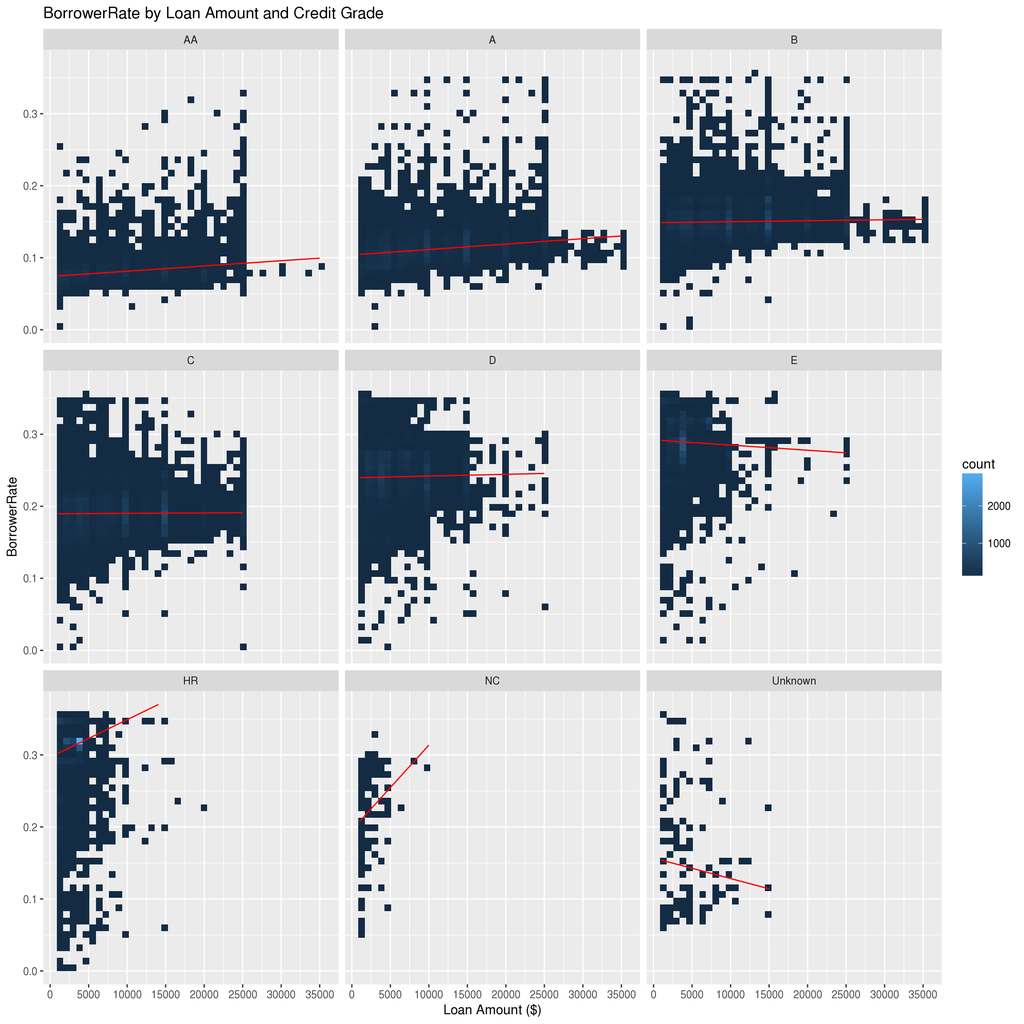

### Description Three

This plot reveals the different types of borrowers and how their credit grade affects their borrower rate and their maximum available loan amount. It also shows the focus of each type of borrower: especially borrowers with “E” and HR" credit grade obviously favor consumer loans.

# Reflection

I found the dataset to be highly fascinating. The dataset gave me a glimpse behind the curtain of the industry. I have no finance or banking background, and I only heard about peer-2-peer lending businesses on TV ads.  
This circumstance proved to be difficult, as there is a lot of industry-specific nomenclature (e.g. the meaning of different loan status) and the whole loan lifecycle was new to me. I first had to understand the main concepts, before I could start with a reasonable data exploration. On a technical level, I found ggplot2 to be very versatile, but also pretty brittle in some circumstances. For example, I could use scale_x_log10() + geom_bin2d() without problems, but coord_trans(x = “log10”) would not work. Another issue was overplotting with geom_point(); as certain numeric variables (e.g. BorrowerRate) only had a small number of distinct values, the usual techniques to avoid overplotting would not work.

Proper data preparation was certainly one of the success factors for the analysis. Having ordered factors makes plotting so much easier; ggplot2 can also use variables with correct date and time datatype directly and chooses the right axis labels automatically. For example, GGpairs would only run efficiently with LoanSetupTime being numeric, but would take forever with LoanSetupTime being datediff datatype.

The analysis could easily be enriched in future work, if the complete loan lifecycle was available as a dataset. The dataset contained listing details only as far as they are relevant to the loan, but the lifecycle of a listing would be interesting as well.

Another idea for future work could be a mathematical model, that forecasts the loan status based on borrower, listing and loan characteristics. The current dataset contains a lot of currently running loans with at least 3 years of duration, so it would take a while to find out the final loan status. A model could help both Prosper and the borrower avoid troubled loans early on.